# Course synthesis

5 June 2026

## Goals for today

Sit back and reflect on how much you’ve learned

## Learning objectives for the course

- Identify an appropriate statistical model based on the data and specific question
- Understand the assumptions behind a chosen statistical model
- Use **R** to fit a variety of linear models to data
- Evaluate data support for various models and select the most parsimonious model among them
- Use **R Markdown** to combine text, equations, code, tables, and figures into reports

## Simple linear models

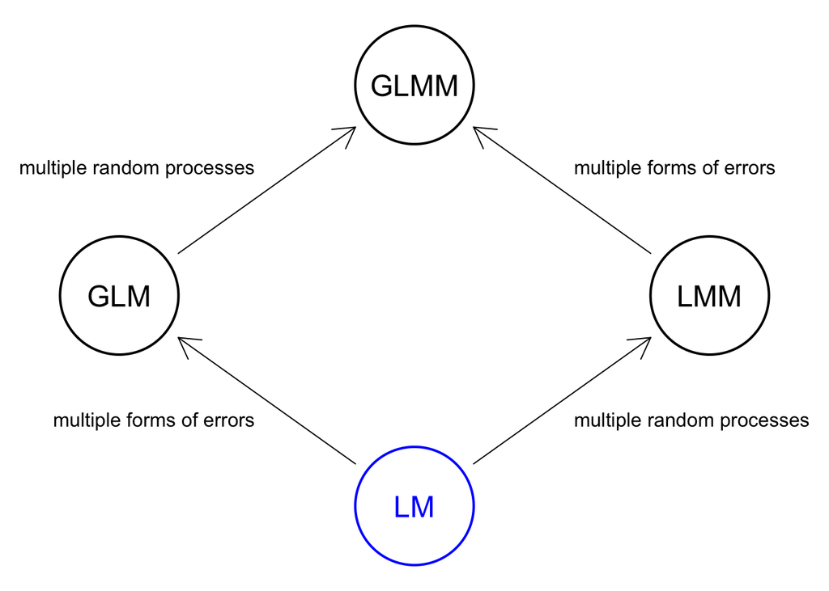

## Partitioning total deviations

The total deviations in the data equal the sum of those for the model and errors

\[ \underbrace{y_i - \bar{y}}_{\text{Total}} = \underbrace{\hat{y}_i - \bar{y}}_{\text{Model}} + \underbrace{y_i - \hat{y}_i}_{\text{Error}} \]

## Partitioning total deviations

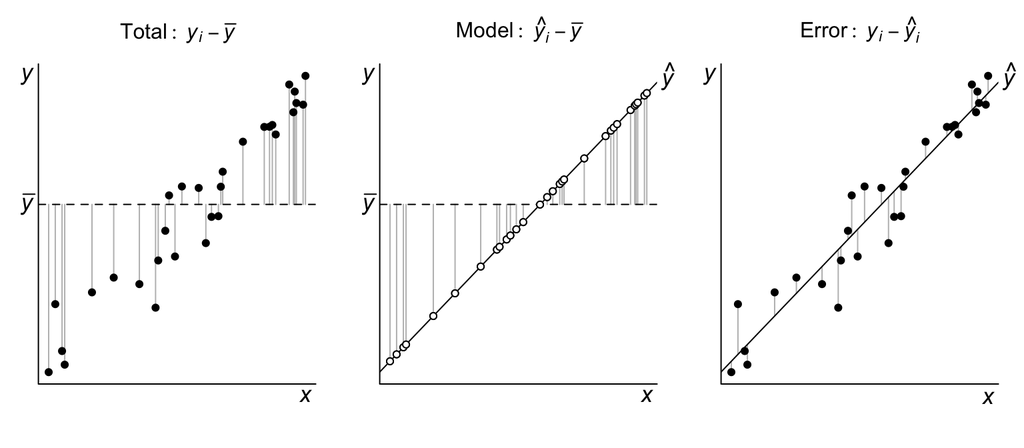

## Partitioning sums-of-squares

The sums-of-squares have the same additive property as the deviations

\[ \underbrace{\sum (y_i - \bar{y})^2}_{SSTO} = \underbrace{\sum (\hat{y}_i - \bar{y})^2}_{SSR} + \underbrace{\sum (y_i - \hat{y}_i)^2}_{SSE} \]

## Linear models in matrix form

\[ y_i = \beta_0 + \beta_1 x_{1,i} + \beta_2 x_{2,i} + e_i \\ \Downarrow \\ \begin{bmatrix} y_1 \\ y_2 \\ \vdots \\ y_N \end{bmatrix} = \begin{bmatrix} 1 & x_{1,1} & x_{2,1} \\ 1 & x_{1,2} & x_{2,2} \\ \vdots & \vdots \\ 1 & x_{1,N} & x_{2,N} \end{bmatrix} \begin{bmatrix} \beta_0 \\ \beta_1 \\ \beta_2 \end{bmatrix} + \begin{bmatrix} e_1 \\ e_2 \\ \vdots \\ e_N \end{bmatrix} \\ \Downarrow \\ \mathbf{y} = \mathbf{X} \boldsymbol{\beta} + \mathbf{e} \]

## Ordinary least squares

Rewriting our model, we have

\[ \mathbf{y} = \mathbf{X} \hat{\boldsymbol{\beta}} + \mathbf{e} \\ \Downarrow \\ \mathbf{e} = \mathbf{y} - \mathbf{X} \hat{\boldsymbol{\beta}} \]

so the sum of squared errors is

\[ \mathbf{e}^{\top} \mathbf{e} = (\mathbf{y} - \mathbf{X} \hat{\boldsymbol{\beta}})^{\top} (\mathbf{y} - \mathbf{X} \hat{\boldsymbol{\beta}}) \]

## Ordinary least squares

Minimizing the sum of squared errors leads to

\[ \hat{\boldsymbol{\beta}} = (\mathbf{X}^{\top} \mathbf{X})^{-1} \mathbf{X}^{\top} \mathbf{y} \\ \Downarrow \\ \hat{\mathbf{y}} = \mathbf{X} \hat{\boldsymbol{\beta}} \]

## Variance estimates

### Parameters

The variance of \(\hat{\boldsymbol{\beta}}\) is given by

\[ \text{Var}(\hat{\boldsymbol{\beta}}) = \sigma^2 (\mathbf{X}^{\top} \mathbf{X})^{-1} \]

This suggests that our confidence in our estimate increases with the spread in \(\mathbf{X}\)

## Effect of \(\mathbf{X}\) on parameter precision

Consider these two scenarios where the slope of the relationship is identical

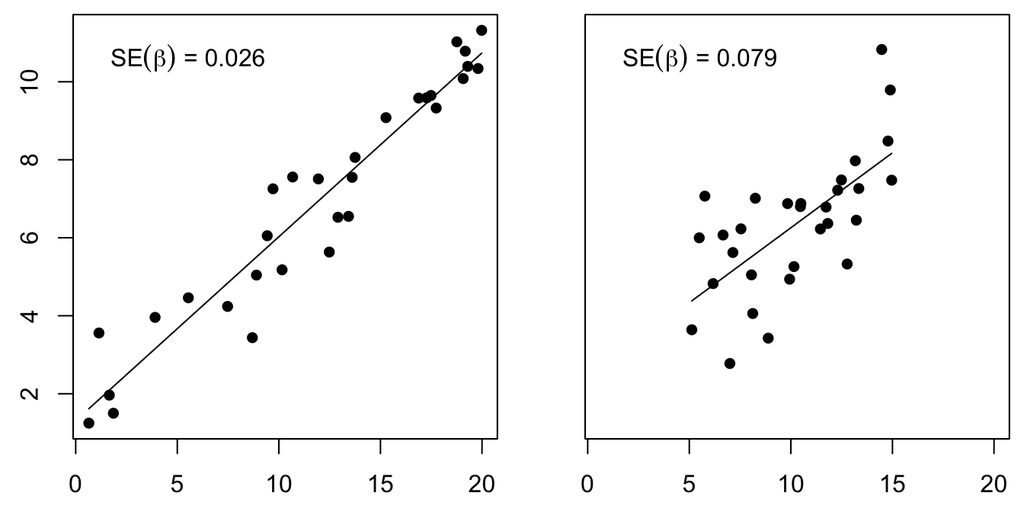

## CI for the mean response

A CI for the mean response is given by

\[ \hat{\mathbf{y}}^* \pm ~ t^{(\alpha / 2)}_{df} \sigma \sqrt{ {\mathbf{X}^*}^{\top} (\mathbf{X}^{\top} \mathbf{X})^{-1} \mathbf{X}^* } \]

## CI for a specific response

A CI on a new prediction is given by

\[ \hat{\mathbf{y}}^* \pm ~ t^{(\alpha / 2)}_{df} \sigma \sqrt{1 + {\mathbf{X}^*}^{\top} (\mathbf{X}^{\top} \mathbf{X})^{-1} \mathbf{X}^* } \]

This is typically referred to as the *prediction interval*

## Diagnostics

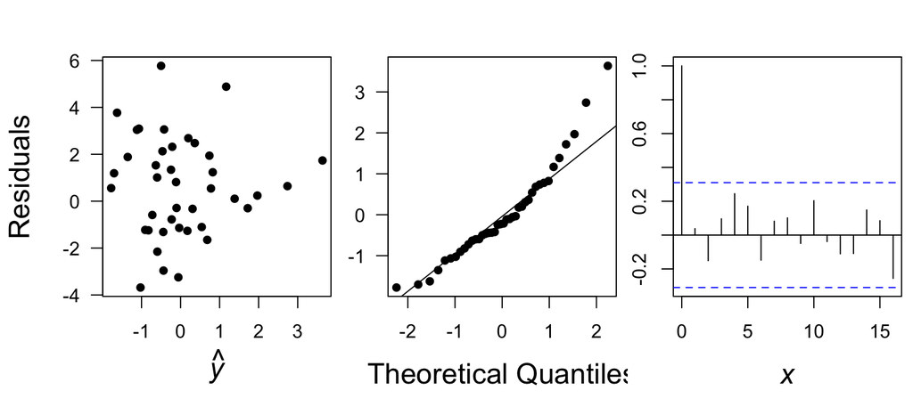

## Unusual observations

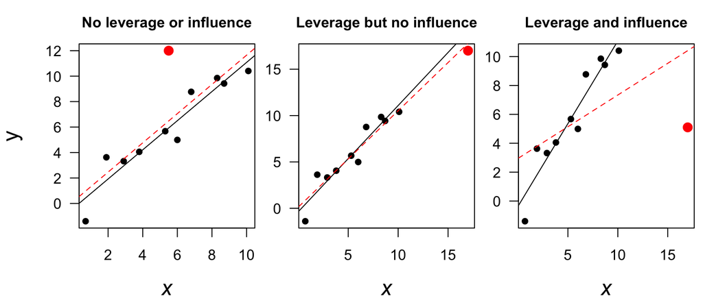

## Bias versus variance

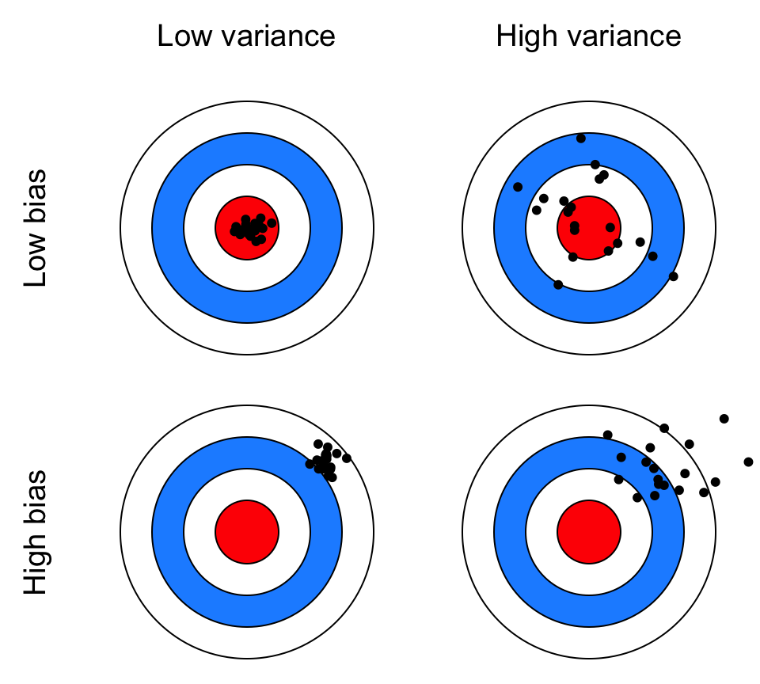

## Bias-variance trade-off

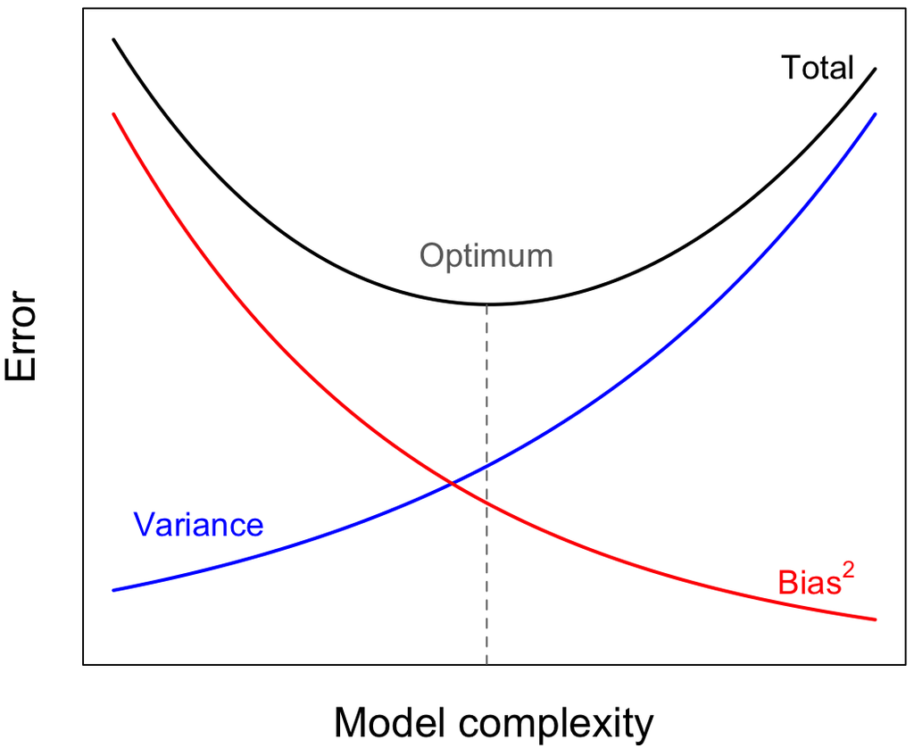

## Model selection

### In-sample

### Null hypothesis testing

- \(F\) test, likelihood ratio test, \(\chi^2\) test

### Regularization

- AIC, QAIC, BIC

## Model selection

### Out-of-sample

### Cross validation

- leave-\(k\)-out

## Linear mixed models

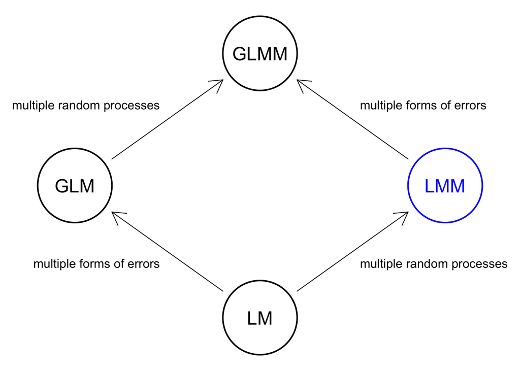

## Fixed vs random effects

Fixed effects describe *specific levels* of factors that are *not* part of a larger group

Random effects describe *varying levels* of factors drawn from a larger group

## Model for means

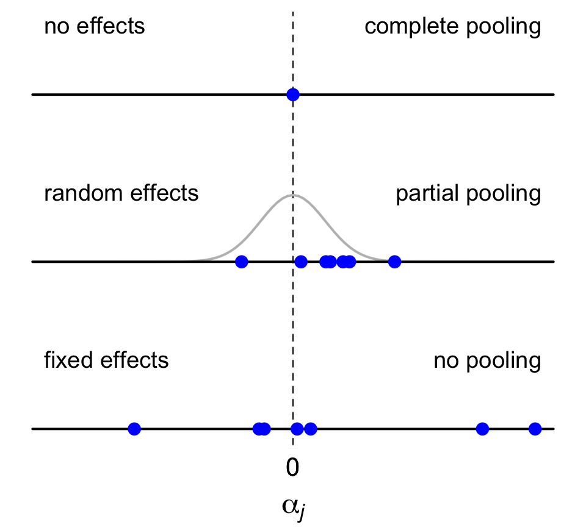

## Linear mixed model

We can extend the general linear model to include both of fixed and random effects

\[ \mathbf{y} = \mathbf{X} \boldsymbol{\beta} + \mathbf{Z} \boldsymbol{\alpha} + \mathbf{e} \\ ~ \\ \mathbf{e} \sim \text{MVN}(\mathbf{0}, \sigma^2 \mathbf{I}) \\ ~ \\ \boldsymbol{\alpha} \sim \text{MVN}(\mathbf{0}, \sigma^2 \mathbf{D}) \]

## Restricted maximum likelihood

Estimating the parameters in a mixed effects model requires *restricted maximum likelihood* (REML)

REML works by

1. estimating the fixed effects \((\hat{\boldsymbol{\beta}})\) via ML
2. using the \(\hat{\boldsymbol{\beta}}\) to estimate the \(\hat{\boldsymbol{\alpha}}\)

## Model selection

To use AIC, we can follow these steps

1. Fit a model with *all* of the possible fixed-effects included
2. Keep the fixed effects constant and search for random effects
3. Keep random effects as is and fit different fixed effects

## Generalized linear models

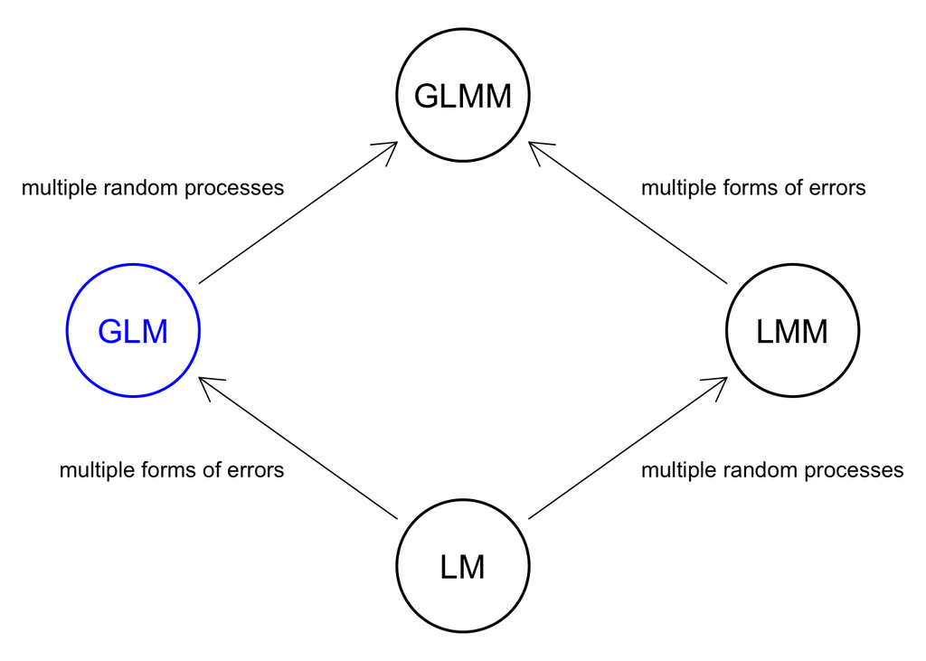

## Generalized linear models (GLMs)

*Three important components*

1. Distribution of the data \(y \sim f_{\theta}(y)\)
2. Link function \(g(\eta)\)
3. Linear predictor \(\eta = \mathbf{X} \boldsymbol{\beta}\)

## Common link functions

| Distribution | Link function | Mean function |
| --- | --- | --- |
| Identity | \(1(\mu) = \mathbf{X} \boldsymbol{\beta}\) | \(\mu = \mathbf{X} \boldsymbol{\beta}\) |
| Log | \(\log (\mu) = \mathbf{X} \boldsymbol{\beta}\) | \(\mu = \exp (\mathbf{X} \boldsymbol{\beta})\) |
| Logit | \(\log \left( \frac{\mu}{1 - \mu} \right) = \mathbf{X} \boldsymbol{\beta}\) | \(\mu = \frac{\exp (\mathbf{X} \boldsymbol{\beta})}{1 + \exp (\mathbf{X} \boldsymbol{\beta})}\) |

## Logistic regression for binary response

We need 3 things to specify our GLM

1. Distribution of the data: \(y \sim \text{Bernoulli}(p)\)
2. Link function: \(\text{logit}(p) = \log \left( \frac{p}{1 - p} \right) = \eta\)
3. Linear predictor: \(\eta = \mathbf{X} \boldsymbol{\beta}\)

## Logistic regression for proportions

We need 3 things to specify our GLM

1. Distribution of the data: \(y \sim \text{Binomial}(N, p)\)
2. Link function: \(\text{logit}(p) = \log \left( \frac{p}{1 - p} \right) = \eta\)
3. Linear predictor: \(\eta = \mathbf{X} \boldsymbol{\beta}\)

## Overdispersion

The variance is larger than expected

Overdispersion generally arises in 2 ways related to IID errors

1. trials occur in groups & \(p\) is not constant among groups
2. trials are not independent

## Overdispersion

We can estimate the dispersion \(c\) from the deviance \(D\) as

\[ \hat{c} = \frac{D}{n - k} \]

or from Pearson’s \(\chi^2\) as

\[ \hat{c} = \frac{X^2}{n - k} \]

## Effects on parameter estimates

The estimate of \(\hat{\boldsymbol{\beta}}\) is *not* affected by overdispersion…

but the variance of \(\hat{\boldsymbol{\beta}}\) *is* affected, such that

\[ \text{Var}(\hat{\boldsymbol{\beta}}) = \hat{c} \left( \mathbf{X}^{\top} \hat{\mathbf{W}} \mathbf{X} \right)^{-1} \]

## Options for overdispersed proportions

| Model | Pros | Cons |
| --- | --- | --- |
| binomial | Easy | Underestimates variance |
| binomial with VIF | Easy; estimate of variance | Ad hoc |
| quasi-binomial | Easy; estimate of variance | No distribution for inference |
| beta-binomial | Strong foundation | Somewhat hard to implement |

## Counts vs proportions

With count data, we only know the *frequency of occurrence*

That is, how often something occurred without knowing how often it *did not occur*

## Poisson regression

Counts \((y_i)\) as a function of covariates

\[ \begin{aligned} \text{data distribution:} & ~~ y_i \sim \text{Poisson}(\lambda_i) \\ \\ \text{link function:} & ~~ \text{log}(\lambda_i) = \mu_i \\ \\ \text{linear predictor:} & ~~ \mu_i = \mathbf{X} \boldsymbol{\beta} \end{aligned} \]

## General variance for count data

We can consider the possibility that the variance scales linearly with the mean

\[ \text{Var}(y) = c \lambda \]

If \(c\) = 1 then \(y \sim \text{Poisson}(\lambda)\)

If \(c\) > 1 the data are *overdispersed*

## Overdispersed regression

Counts \((y_i)\) as a function of covariates

\[ \begin{aligned} \text{data distribution:} & ~~ y_i \sim \text{negBin}(r, \mu_i) \\ \\ \text{link function:} & ~~ \text{log}(\mu_i) = \eta_i \\ \\ \text{linear predictor:} & ~~ \eta_i = \mathbf{X} \boldsymbol{\beta} \end{aligned} \]

## Zero-truncated data

Zero-truncated data cannot take a value of 0

Although somewhat rare in ecological studies, examples include

- time a whale is at the surface before diving
- herd size in elk
- number of fin rays on a fish

## Poisson for zero-truncated data

The probability that \(y_i = 0\) and \(y_i \neq 0\)

\[ f(y_i = 0; \lambda_i) = \exp (\text{-} \lambda_i) \\ \Downarrow \\ f(y_i \neq 0; \lambda_i) = 1 - \exp (\text{-} \lambda_i) \]

## Poisson for zero-truncated data

We can exclude the probability that \(y_i = 0\) by dividing the pmf by the probability that \(y_i \neq 0\)

\[ f(y_i; \lambda_i) = \frac{\exp (\text{-} \lambda_i) \lambda_{i}^{y_i}}{y_i!} \\ \Downarrow \\ f(y_i; \lambda_i | y_i > 0) = \frac{\exp (\text{-} \lambda_i) \lambda_{i}^{y_i}}{y_i!} \cdot \frac{1}{1 - \exp (\text{-} \lambda_i)} \\ \Downarrow \\ \log \mathcal{L} = \left( y_i \log \lambda_i - \lambda_i \right) - \left( 1 - \exp (\text{-} \lambda_i) \right) \]

## Neg binomial for zero-truncated data

We can exclude the probability that \(y_i = 0\) by dividing the pmf by the probability that \(y_i \neq 0\)

\[ f(y; r, \mu) = \frac{(y+r-1) !}{(r-1) ! y !} \left( \frac{r}{\mu + r} \right)^{r} \left( \frac{\mu}{\mu + r} \right)^{y} \\ \Downarrow \\ f(y_i; \lambda_i | y_i > 0) = \frac{ \frac{(y+r-1) !}{(r-1) ! y !} \left( \frac{r}{\mu + r} \right)^{r} \left( \frac{\mu}{\mu + r} \right)^{y} }{ 1 - \left( \frac{r}{\mu + r} \right)^{r} } \\ \Downarrow \\ \log \mathcal{L} = \log \mathcal{L}(\text{NB}) - \log \left( 1 - \left( \frac{r}{\mu + r} \right)^{r} \right) \]

## Zeros in ecological data

Lots of count data are *zero-inflated*

The data contain more zeros than would be expected under a Poisson or negative binomial distribution

## Sources of zeros

In general, there are 4 different types of errors that cause zeros

1. Structural (animal absent because the habitat is unsuitable)
2. Design (sampling is limited temporally or spatially)
3. Observer error (inexperience or difficult circumstances)
4. Process error (habitat is suitable but unused)

## Approaches to zero-inflated data

There are 2 general approaches for dealing with zero-inflated data

1. Zero-altered (“hurdle”) models
2. Zero-inflated (“mixture”) models

## Hurdle models

Hurdle models do not discriminate among the 4 types of zeros

The data are treated as 2 distinct groups:

1. Zeros
2. Non-zero counts

## Hurdle models

Hurdle models consist of 2 parts

1. Use a binomial model to determine the probability of a zero
2. If non-zero (“over the hurdle”), use a truncated Poisson or negative binomial to model the positive counts

## Zero-inflated (mixture) models

Zero-inflated (mixture) models treat the zeros as coming from 2 sources

1. observation errors (missed detections)
2. ecological (function of environment)

## Mixture models

Zero-inflated (mixture) models consist of 2 parts

1. Use a binomial model to determine the probability of a zero
2. Use a Poisson or negative binomial to model counts, which can include zeros

## Sources of zeros and approaches

| Source | Reason | Over-dispersion | Zero inflation | Approach |
| --- | --- | --- | --- | --- |
| Random | Sampling variability | No | No | Poisson |
|  |  | Yes | No | Neg binomial |
| Structural | Outside count process | No | Yes | ZAP or ZIP |
|  |  | Yes | Yes | ZANB or ZINB |

## Generalized linear mixed models

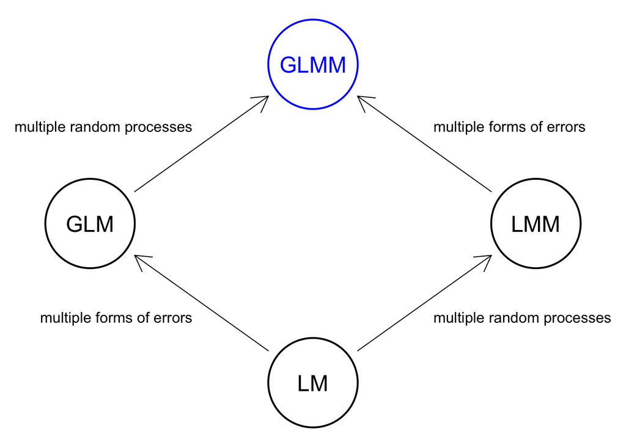

## Generalized linear mixed model

GLMMs combine the flexibility of non-normal distributions (GLMs) with the ability to address correlations among observations and nested data structures (LMMs)

## Generalized linear mixed model

Good news

- these extensions follow similar methods to GLMs and LMMs

Bad news

- these models are on the frontier of statistical research
- existing documentation is rather technical
- multiple approaches for fitting models; some with different results

## Generalized linear mixed model

Just like GLMs, GLMMs have three components:

1. Distribution of the data \(f(y; \theta)\)
2. Link function \(g(\eta)\)
3. Linear predictor \(\eta\)

## Linear predictor for a GLMM

For GLMMs, our linear predictor also includes random effects

\[ \eta = \beta_0 + \beta_1 x_1 + \dots + \beta_k x_k + \alpha_0 + \alpha_1 z_1 + \dots + \alpha_l z_l\\ \Downarrow \\ \eta = \mathbf{X} \boldsymbol{\beta} + \mathbf{Z} \boldsymbol{\alpha} \]

where the \(\beta_i\) are fixed effects of the covariates \(x_i\)

## Generalized linear mixed model

\[ \begin{aligned} \text{data distribution:} & ~~~ y_{i,j} \sim \text{Binomial}(N_{i,j}, s_{i,j}) \\ \text{link function:} & ~~~ \text{logit}(s_{i,j}) = \text{log}\left(\frac{s_{i,j}}{1-s_{i,j}}\right) = \mu_{i,j} \\ \text{linear model:} & ~~~ \mu_{i,j} = (\beta_0 + \alpha_j) + (\beta_1 + \delta_j) x_{i,j} \\ & ~~~ \alpha_j \sim \text{N}(0, \sigma_{\alpha}^2) \\ & ~~~ \delta_j \sim \text{N}(0, \sigma_{\delta}^2) \end{aligned} \]

## Summary of GLMM methods

| Method | Advantages | Disadvantages | R functions |
| --- | --- | --- | --- |
| Penalized quasi-likelihood | Flexible, widely implemented | inference may be inappropriate; potentially biased | `MASS::glmmPQL` |
| Laplace approximation | More accurate than PQL | Slower and less flexible than PQL | `lme4::glmer` `glmmsr::glmm` `glmmML::glmmML` |
| Gauss-Hermite quadrature | More accurate than Laplace | Slower than Laplace; limited random effects | `lme4::glmer` `glmmsr::glmm` `glmmML::glmmML` |

## Some parting advice

## Lesson number 1

A good analysis begins with a good question

## Lesson number 2

A good analysis doesn’t have to be complicated

- A clean and reproducible analysis is always best
- Keep the explanation clean and elegant too

## Lesson number 3

Stay as close to the data as possible

- Try to work with the raw data
- Beware of “stats on stats”

## Lesson number 4

Know thy model

## Lesson number 4

Know thy model

Everyone should be clear on (at least) three things:

1. What is your model (set)?
2. Why is it your model (set)?
3. How will inference from your model (set) answer your question?

## Lesson number 5

Assumptions matter

- Inference is conditional on the degree to which we meet our assumptions
- Be very clear, and allow our reader to be very clear, on our assumptions

## Lesson number 6

Be your own (best) critic

- Look for the holes & confess them
- If you can’t fix them, there is still value in the analysis
- Maybe someone in the future (you?) will fix/solve them

## Lesson number 7

Learning is a lifelong process